# Coursework Report

[output not shown]

**Main analysis results**

[interactive chart not shown]

[figure not shown]

[interactive chart not shown]

# Coursework Report

Analysing Data, Spring 2020

# Methods

## Participants

The orginal number of partipants were 150 females with ages ranging from 2 to 26 years old hence a range of 24 years. After removing the data of participants below 17 years old (3) and also removing data including the NA/s (13). The total number of participants were 134. The mean age was 20.48 a standard deviation of 2.1 a mimium of 17 and maxium of 26, which is depicted in both the table and the histogram

Table 1- Descriptive statistics by age

| Mean age | Standard deviation of age | min age | max age |
| --- | --- | --- | --- |
| 20.48 | 2.1 | 17 | 26 |

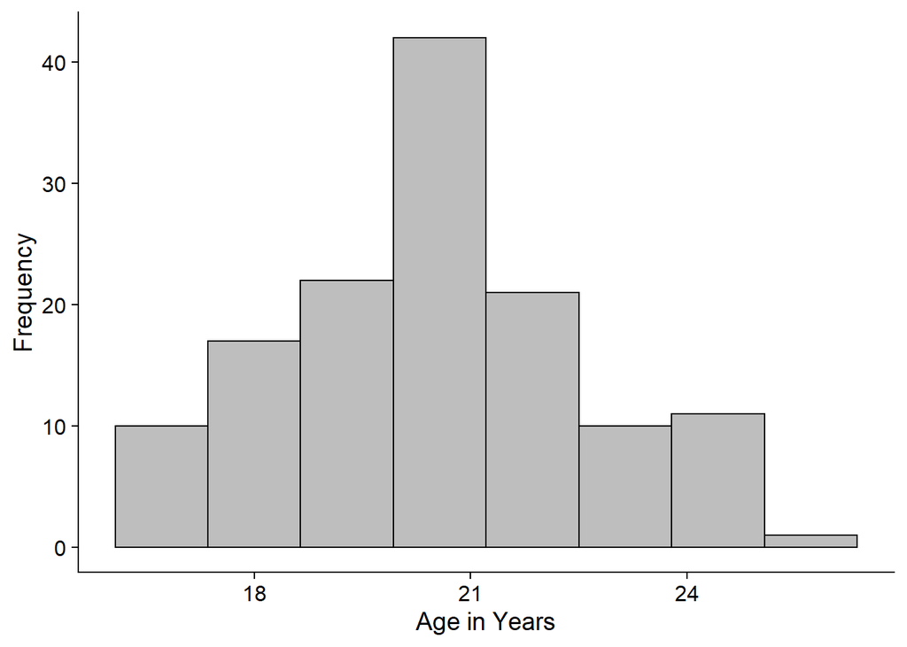

## Design

There were 3 questions in which a participant would answer to either a black-and-white photo of a man with a red frame(experimental condition) or white frame (control condition). The photograph displayed the man’s face in a neural expression and cropped at the upper back. The questions were “How attractive do you think this person is?” “How pleasant is this person to look at?” and “If I were to meet the person in this picture face to face,would I think he is attractive.” The participants in response to these questions were asked to rate the man on a likert scale changing from 1-9. For example for question 1 a rating of 9 would mean the participant thought the man in the picture was extremely atrractive whereas 1 would mean not attrcative at all.The answers of the 3 questions were combined to get a composite score for each condition. In this experiment the indepedent varibale was whether the participant saw a red or white frame around the photograph of the man. The depedant variable was the mean attractiveness rating for the 3 questions.

# Result

[figure not shown]

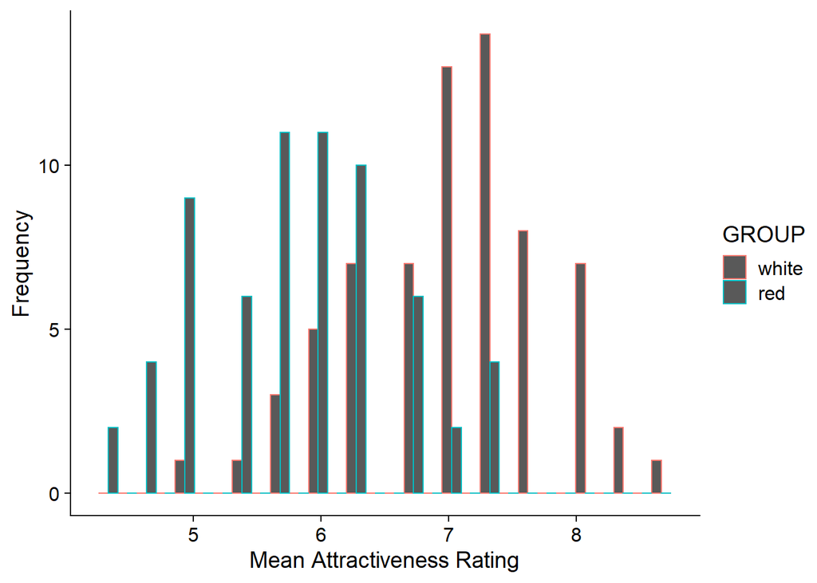

```
##
##  Two Sample t-test
##
## data:  composite_mean by GROUP
## t = 9.054, df = 132, p-value = 0.000000000000001578
## alternative hypothesis: true difference in means is not equal to 0
## 95 percent confidence interval:
##  0.9286484 1.4478659
## sample estimates:
## mean in group white   mean in group red
##            7.024155            5.835897
```

T independant-measures *t*-test depicted that the there was a difference between the means (*M*<sub>diff</sub> = 1.19, 95% CI [0.93, 1.45]), hence the confidence interval of 1.19 is quite large of a rating from 1-9. which suggests that the difference is significant.

Even though there was a significant difference between the means one must reject the operationalised hypothesis as white condition caused atrractiveness ratings to significantly increase, not the red condition. Hence the colour red does not have an affect on attractivness rating.

# Discussion

The operational hypothesis is defined as if participants saw a man in a red frame, they would perceive him as more sexually attractive whereby they would score them more highly in Likert scale ranging 1-9 than if the man was in a white frame. This would suggest regarding the conceptual hypothesis (does colour influence attractiveness) that red does indeed influence the females sexual attractiveness to men.

The present research does not give support to the red effect, as in the white frame condition when a man was photoshopped onto a white frame it caused a higher mean average of attractiveness rating than a man on a red background which indicates that red didn’t have an effect on a women’s perception of sexual attractiveness. The *t* = 9.05 depicted that the results were significantly different, yet in contrast, to the operationalised hypothesis the significance indicated that the colour white had a greater effect than red on women’s perception of sexual attraction.

The present study contradicts the evidence by (Elliot et al., 2010) in which the rating for men shirt was significantly higher than man dressed in a white shirt. However, the differences in the finding could be due to red as the clothing as is artificial red. Also (Elliot & Niesta, 2008) supported that the colour red had a significant effect on women attractiveness rating for men as men in a red shirt received higher attractiveness rating than men in blue shirt. However, the reason for the differing results to the present study could be due the study examined if red enhances men’s attraction to women hence suggesting that the causation of sexual attraction differs between men and women, hence why red affects mens perception yet not women’s perception of sexual attractivness.

However, (Peperkoorn et al., n.d.) findings were parallel to the present findings in which the white condition caused participants to score higher in attractiveness rating. This suggested that further evidence could be obtained in the influence of white in affecting perceived attractiveness. However, in that study it was measuring the influence of colour upon men not women, hence this can only support the present studies finding to a certain extent as the studies had different samples populations.

The present study incurred limitations through obtaining a sample population of only 17-26 the lack of age variation meant the results could not be generalised to older or younger populations. Also, the sample was taken from Sussex university students hence the sample is culturally biased and hence the results are not cross culturally generalisable. Moreover some cross culture studies have given evidence that the red effect does influence attraction in other cultures for example in Burkina Faso, male participants scored women higher in attractiveness rating when they wore red compare to a control condition (Elliot et al., 2013) cited in (Peperkoorn et al., n.d.) This suggests that if the present research did include a variation of cultures the results could be been different and supported of the operational hypothesis.

The mechanisms behind white causing greater attractiveness has not been questioned, could it be because it symbolises of “chastity, purity, high virtues, and innocence” (Anishchanka, Zhang, et al., 2011; Aslam, 2006; Grieve, 1991; Hutchings, 2004; Monger, 2004) cited from (Peperkoorn et al., n.d.) which is shown to be important for long term mating decisions. Therefore follow up studies with the same population sample could be necessary to determine if the symbolism of the white affected the scoring for sexual attraction of the men in both the long and short term mating decision.

# References

Anishchanka, A. V., Zhang, W., & Phlip, G. (2011). Colouring Meaning: Collocation and Connotation in Figurative Language. Metaphor and the Social World, 2(1), 121–129. https://doi.org/10.1075/msw.2.1.07ani

Aslam, M. M. (2006). Are You Selling the Right Colour? A Cross‐cultural Review of Colour as a Marketing Cue. Journal of Marketing Communications, 12(1), 15–30. https://doi.org/10.1080/13527260500247827

Elliot, A. J., & Niesta, D. (2008). Romantic red: Red enhances men’s attraction to women. Journal of Personality and Social Psychology, 95(5), 1150–1164. https://doi.org/10.1037/0022-3514.95.5.1150

Elliot, A. J., Niesta Kayser, D., Greitemeyer, T., Lichtenfeld, S., Gramzow, R. H., Maier, M. A., & Liu, H. (2010). Red, rank, and romance in women viewing men. Journal of Experimental Psychology: General, 139(3), 399–417. https://doi.org/10.1037/a0019689

Elliot, A. J., Pazda, A. D., Beall, A. T., & Tracy, J. L. (2013). Red enhances womens attractivness to men: First evidence suggesting universality. Journal of Experimental Social Psychology, 49, 165–168.

Grieve, K. W. (1991). Traditional Beliefs and Colour Perception. https://journals.sagepub.com/doi/abs/10.2466/pms.1991.72.3c.1319

Hutchings, J. (2004). Colour in folklore and tradition—The principles. Color Research & Application, 29(1), 57–66. https://doi.org/10.1002/col.10212

Monger, G. (2004). Marriage Customs of the World: From Henna to Honeymoons. ABC-CLIO.

Peperkoorn et al. (n.d.). Revisiting the Red Effect on Attractiveness and Sexual Receptivity: No Effect of the Color Red on Human Mate Preferences -. Retrieved October 28, 2019, from https://journals.sagepub.com/doi/full/10.1177/1474704916673841